# QTM 151 Final Project

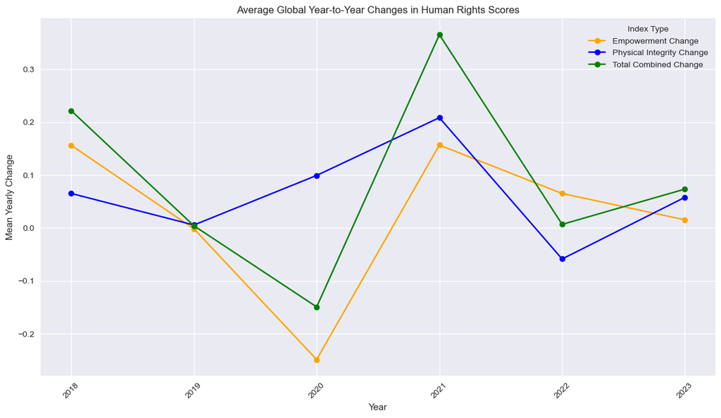

```python
df1 = pd.read_csv('csv files/cpr.csv')
df = df1[['country', 'year', 'physint_mean', 'empower_mean']].dropna()
df = df.sort_values(['country', 'year'])

df['physint_change'] = df.groupby('country')['physint_mean'].diff()
df['empower_change'] = df.groupby('country')['empower_mean'].diff()
df['total_change'] = df['physint_change'] + df['empower_change']

df_change = df.dropna(subset=['total_change'])

yearly_avg = df_change.groupby('year')[['physint_change', 'empower_change', 'total_change']].mean().reset_index()

long_avg = yearly_avg.melt(
    id_vars='year',
    value_vars=['physint_change', 'empower_change', 'total_change'],
    var_name='Index',
    value_name='Average Change'
)

long_avg['Index'] = long_avg['Index'].map({
    'physint_change': 'Physical Integrity Change',
    'empower_change': 'Empowerment Change',
    'total_change': 'Total Combined Change'
})

color_map = {
    'Physical Integrity Change': 'blue',
    'Empowerment Change': 'orange',
    'Total Combined Change': 'green'
}

plt.figure(figsize=(12, 7))

for label, group in long_avg.groupby('Index'):
    plt.plot(group['year'], group['Average Change'], label=label, color=color_map[label], marker='o')

plt.title('Average Global Year-to-Year Changes in Human Rights Scores')
plt.xlabel('Year')
plt.ylabel('Mean Yearly Change')
plt.xticks(yearly_avg['year'].unique(), rotation=45)
plt.grid(True)
plt.legend(title='Index Type')
plt.tight_layout()
plt.show()
```

This graph shows the average global year-to-year changes in human rights scores from 2018 to 2023, broken down by physical integrity, empowerment, and their combined total. Overall, the trends are unstable and vary from year to year, suggesting that global human rights progress has not followed a consistent upward path. In 2020, there is a noticeable drop in both empowerment and total change, likely linked to global political crackdowns and emergency restrictions during the COVID-19 pandemic. This is followed by a sharp recovery in 2021, especially in total combined scores, but the momentum is not sustained. By 2022 and 2023, the lines flatten out again, with only small positive shifts. The graph suggests that while temporary gains and losses occur, the world as a whole is not moving steadily toward stronger human rights protections.

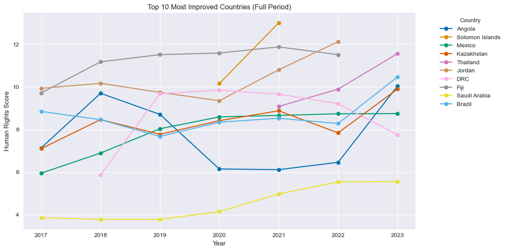

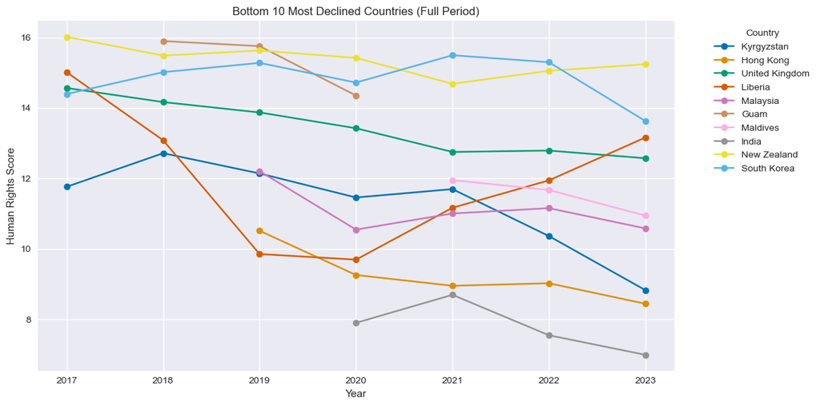

```python
df1 = pd.read_csv('csv files/cpr.csv')
df = df1[['country', 'year', 'physint_mean', 'empower_mean']].dropna()
df = df.sort_values(['country', 'year'])

df['total_score'] = df['physint_mean'] + df['empower_mean']

change_records = []

for country in df['country'].unique():
    country_df = df[df['country'] == country]
    first_year = country_df['year'].min()
    last_year = country_df['year'].max()
    first_score = country_df[country_df['year'] == first_year]['total_score'].values[0]
    last_score = country_df[country_df['year'] == last_year]['total_score'].values[0]
    change_records.append({
        'country': country,
        'start_year': first_year,
        'end_year': last_year,
        'start_score': first_score,
        'end_score': last_score,
        'score_change': last_score - first_score
    })

change_df = pd.DataFrame(change_records)

top_10 = change_df.sort_values('score_change', ascending=False).head(10)['country'].tolist()
bottom_10 = change_df.sort_values('score_change').head(10)['country'].tolist()

df_top = df[df['country'].isin(top_10)]
df_bottom = df[df['country'].isin(bottom_10)]

# Plot Top 10
plt.figure(figsize=(12, 6))
for country in top_10:
    country_data = df_top[df_top['country'] == country]
    plt.plot(country_data['year'], country_data['total_score'], label=country, marker='o')

plt.title('Top 10 Most Improved Countries (Full Period)')
plt.xlabel('Year')
plt.ylabel('Human Rights Score')
plt.legend(title='Country', bbox_to_anchor=(1.05, 1), loc='upper left')
plt.grid(True)
plt.tight_layout()
plt.show()

# Plot Bottom 10
plt.figure(figsize=(12, 6))
for country in bottom_10:
    country_data = df_bottom[df_bottom['country'] == country]
    plt.plot(country_data['year'], country_data['total_score'], label=country, marker='o')

plt.title('Bottom 10 Most Declined Countries (Full Period)')
plt.xlabel('Year')
plt.ylabel('Human Rights Score')
plt.legend(title='Country', bbox_to_anchor=(1.05, 1), loc='upper left')
plt.grid(True)
plt.tight_layout()
plt.show()
```

## Results

Looking at all the graphs together, there doesn’t appear to be a strong trade-off between empowerment rights and physical integrity rights—most countries that improve in one generally tend to improve in the other as well, although the relationship is not very strong. Yearly changes are often small and scattered, but countries with higher freedom status tend to show more stable patterns, while “Less Free” and “Partially Free” countries experience greater volatility and wider shifts. Global trends from 2018 to 2023 suggest inconsistency rather than steady progress, with a clear dip around 2020 followed by a short-lived recovery and mostly flat changes in recent years. Countries like Fiji, Jordan, Thailand, and the Solomon Islands appear to have made some of the most noticeable improvements, while Hong Kong, India, Guam, and Kyrgyzstan have experienced steady declines. Together, these patterns suggest that global human rights protections are not clearly improving or deteriorating overall but may instead reflect a mixed and fragile balance, where progress in some places is offset by setbacks in others.

# Research Question 2

To what extent do LGBTQIA+ protections reflect broader civil and political rights in a country, and how do these relationships differ by region, income level, and over time.

To answer this research question, we'll examine:

1. How civil/political rights indicators (like freedom of expression, assembly, and political participation) might serve as proxies for LGBTQIA+ rights protections
2. Regional patterns in these rights
3. Changes over time
4. Relationships between different rights indicators

Explanation: This graph shows how freedom of expression (a key civil right) has changed globally over time. Since freedom of expression is often correlated with LGBTQIA+ rights (countries that protect free expression tend to also protect LGBTQIA+ rights), this serves as a proxy indicator. The trend line shows whether the overall environment for rights protection is improving or declining. It can be noted that in 2019, the freedom of expression shows a peak.

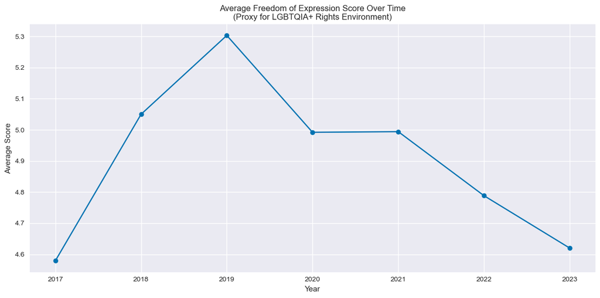

```python
cpr_data = pd.read_csv('csv files/cpr.csv')

plt.figure(figsize=(12, 6))
yearly_express = cpr_data.groupby('year')['express_mean'].mean()
yearly_express.plot(kind='line', marker='o')
plt.title('Average Freedom of Expression Score Over Time\n(Proxy for LGBTQIA+ Rights Environment)')
plt.xlabel('Year')
plt.ylabel('Average Score')
plt.grid(True)
plt.tight_layout()
plt.show()
```